# Predicting Quality of Excercises

Nitesh Kr. Singh

17 March 2017

## Pre-processing

```r
#required libraries
library(caret)
library(corrplot)
library(ggplot2)
library(GGally)
library(Rtsne)
```

```r
#saving the urls of train and test dataset

trainUrl <-"https://d396qusza40orc.cloudfront.net/predmachlearn/pml-training.csv"
testUrl <- "https://d396qusza40orc.cloudfront.net/predmachlearn/pml-testing.csv"

#saving the name of files

trainFile <- "./pml-training.csv"
testFile  <- "./pml-testing.csv"

#if files doesn't exist download them

if (!file.exists(trainFile)) {
  download.file(trainUrl, destfile=trainFile, method="auto")
}
if (!file.exists(testFile)) {
  download.file(testUrl, destfile=testFile, method="auto")
}

set.seed(0)
```

## Synopsis

For this project, we are given data from accelerometers on the belt, forearm, arm, and dumbell of 6 research study participants. Our training data consists of accelerometer data and a label identifying the quality of the activity the participant was doing. Our testing data consists of accelerometer data without the identifying label. Our goal is to predict the labels for the test set observations.

## Part 1: Data

Reading the training dataset into `train` object.

```r
#reading the train dataset

train<-read.csv(trainFile,na.strings = c(NA,"#DIV/0!"),header = TRUE)

head(train,n=1)
```

[output not shown]

[output cut: 25 more lines]

[output not shown]

We can see that the first column is not useful along with the next 5 columns that are only for informative purposes.

So, we will clean our data so that it consists of significant predictors only.For this we are going to remove all the columns with near zero variability and columns with more than 80% values NA.

```r
#removing the first column
train<-train[,-1]

#checking for variables that have zero variability
nzv<-nearZeroVar(train)

#removing variables that will not contribute towards model
train<- train[,-nzv]


#checking for columns that comprise of more than 80% NA values
mostlyNA <- sapply(train, function(x) mean(is.na(x))) > 0.80

#removing columns containing more than 80% NA values
train <- train[, !mostlyNA]

#removing the first five insignificant columns
train<-train[,-(1:5)]
```

## Part 2: Exploratory data analysis

- Fig 1

Plotting a correlation plot to check for redundant variables. Here I have colored the correlations greater than 0.5 as blue and less than -0.5 as red.

As `classe` is not numeric ,to use it in the `ggcorr` function we need to convert it to numeric data.

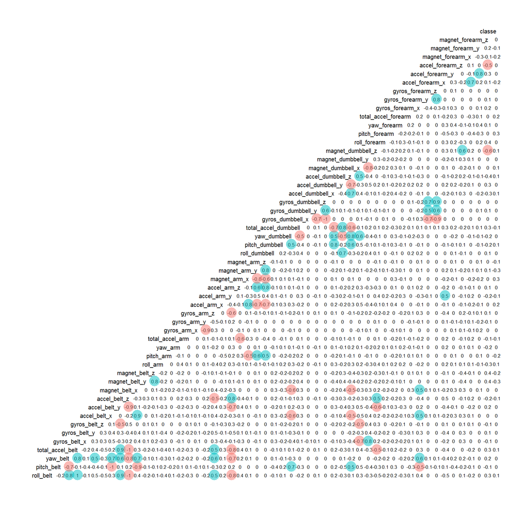

```r
#temporarily saving the train data into 't' object
t<-train

#converting the `classe` column into 'numeric'
t$classe<-as.numeric(t$classe)

#plotting the correlation
ggcorr(t, geom = "blank", label = TRUE, hjust = 1,label_size = 2.2,layout.exp = 5,size=2.7,label_round = 1,label_color = "black") +
    geom_point(size = 6, aes(color = coefficient > 0 , alpha = abs(coefficient) > 0.5)) +
    scale_alpha_manual(values = c("TRUE" = 0.5, "FALSE" = 0)) +
    guides(color = FALSE, alpha = FALSE)
```

```r
#remove t object
rm(t)
```

- Fig 2

t-distributed stochastic neighbor embedding (t-SNE) is a machine learning algorithm for dimensionality reduction developed by Geoffrey Hinton and Laurens van der Maaten.It is a nonlinear dimensionality reduction technique that is particularly well-suited for embedding high-dimensional data into a space of two or three dimensions, which can then be visualized in a scatter plot. Specifically, it models each high-dimensional object by a two- or three-dimensional point in such a way that similar objects are modeled by nearby points and dissimilar objects are modeled by distant points.

Here, I am providing the t-sne plot of the data.

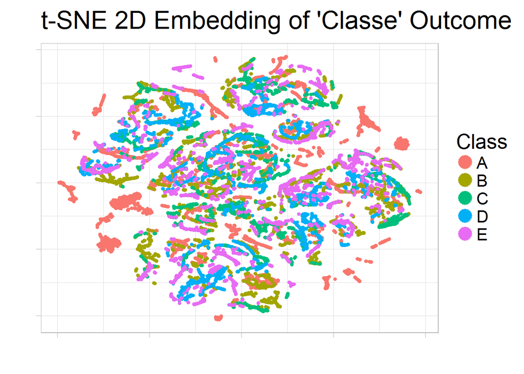

```r
#creating a t-sne of train data
tsne = Rtsne(as.matrix(train[,-ncol(train)]), check_duplicates=FALSE, pca=TRUE,
             perplexity=30, theta=0.5, dims=2)
embedding = as.data.frame(tsne$Y)
embedding$Class = train$classe

#plotting the t-sne data
g = ggplot(embedding, aes(x=V1, y=V2, color=Class)) +
    geom_point(size=1.25) +
    guides(colour=guide_legend(override.aes=list(size=6))) +
    xlab("") + ylab("") +
    ggtitle("t-SNE 2D Embedding of 'Classe' Outcome") +
    theme_light(base_size=20) +
    theme(axis.text.x=element_blank(),
          axis.text.y=element_blank())
print(g)
```

Next we will use machine learning algorithms to achieve the classification task.

## Part 3: Modeling

I was considering to use random forest but it takes too much time to build the model using the following code.

```r
modFit <- train(classe ~ ., method = "rf", data = train, importance = T, trControl = trainControl(method = "cv", number = 10))
```

So, instead I will go for faster gradient boosting algorithm. It will be a bit less accurate but will be significantly faster.

We will use the `trControl` parameter to specify that we will use 10-fold cross validation to evaluate our model.

```r
boostFit <- train(classe ~ ., method = "gbm", data = train, verbose = F, trControl = trainControl(method = "cv", number = 10))
boostFit
```

```
## Stochastic Gradient Boosting
##
## 19622 samples
##    52 predictor
##     5 classes: 'A', 'B', 'C', 'D', 'E'
##
## No pre-processing
## Resampling: Cross-Validated (10 fold)
## Summary of sample sizes: 17659, 17660, 17661, 17660, 17659, 17659, ...
## Resampling results across tuning parameters:
##
##   interaction.depth  n.trees  Accuracy   Kappa
##   1                   50      0.7540009  0.6881121
##   1                  100      0.8217313  0.7743399
##   1                  150      0.8541944  0.8154781
##   2                   50      0.8569981  0.8187546
##   2                  100      0.9055652  0.8804931
##   2                  150      0.9331370  0.9153910
##   3                   50      0.8976658  0.8704341
##   3                  100      0.9440940  0.9292556
##   3                  150      0.9630520  0.9532544
##
## Tuning parameter 'shrinkage' was held constant at a value of 0.1
##
## Tuning parameter 'n.minobsinnode' was held constant at a value of 10
## Accuracy was used to select the optimal model using  the largest value.
## The final values used for the model were n.trees = 150,
##  interaction.depth = 3, shrinkage = 0.1 and n.minobsinnode = 10.
```

## Part 4: Prediction

First we will load the test data set and perform the tranformations that we have performed on the test dataset.

```r
#reading the test data
test<-read.csv(testFile,na.strings = c(NA,"#DIV/0!"),header = TRUE)

head(test,n=1)
```

[output not shown]

[output cut: 25 more lines]

[output not shown]

We can see that `test` consisit of one extra last column that is not needed as it is informative only.

```r
#applying the same transformation that was used to tranform train data
test<-test[,-1]      #removing the first column
test<- test[,-nzv]    #removing variables that are close to zero variability
test <- test[, !mostlyNA]       #removing variables that are mostly NA
test<-test[,-(1:5)]         #removing the fist five columns

test<-test[,-ncol(test)]   #removing the last column
```

Predictions are calculated on the test data and results are printed below.

```r
#predicting the test data
preds<- predict(boostFit,newdata = test)

preds
```

```
##  [1] B A B A A E D B A A B C B A E E A B B B
## Levels: A B C D E
```

## Part 5: Conclusion

We build a classifier to classify the 5 types of the acitivities. Overall accuracy of our model could be increased by using other more computational expensive models such as *random forests*.

( **I am grateful to the providers of the dataset used in this assignment : http://groupware.les.inf.puc-rio.br/har .** )